# Exploratory Analysis of Prince Lyrics

## Descriptive Statistics

To start visualizing and analyzing what we’ve got, we’ll work with Debbie Liske’s preferred color scheme for creating plots.

```r
# define color scheme

dl_colors <- c("#E69F00", "#56B4E9", "#009E73", "#CC79A7", "#D55E00")

# ...and a function for how we'll handle the display

theme_lyrics <- function()
{
  theme(plot.title = element_text(hjust = 0.5),
        axis.text.x = element_blank(),
        axis.ticks = element_blank(),
        panel.grid.major = element_blank(),
        panel.grid.minor = element_blank(),
        legend.position = "none")
}
```

We’ll start by taking a look at songs by decade (filtering out blank “NA” values for years), and using fill colors to indicate what proportion of songs in each decade broke the top 100 chart. The `ggplot` figure will be tweak a bit in the `theme` function.

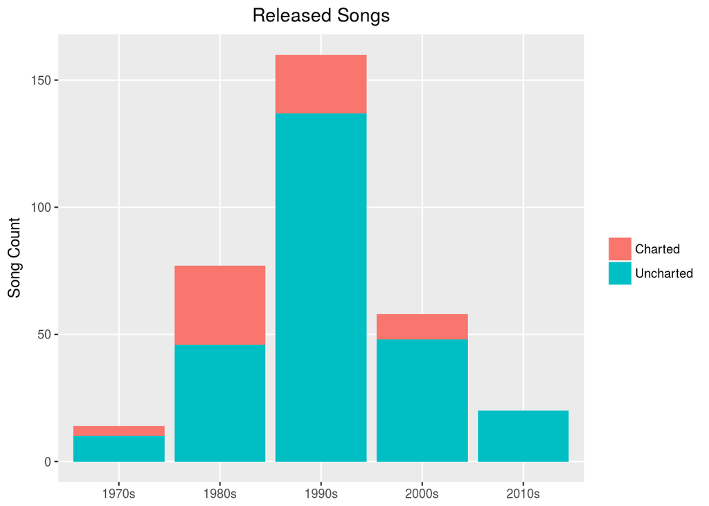

```r
prince %>%
  filter(decade != "NA") %>%
  group_by(decade, charted) %>%
  summarise(songCounts = n()) %>%
  ggplot() +
  geom_bar(aes(x = decade, y = songCounts, fill = charted), stat = "identity") +
  theme(plot.title = element_text(hjust = 0.5),
        legend.title = element_blank(),
        panel.grid.minor = element_blank()) +
  ggtitle("Released Songs") +
  labs(x = NULL, y = "Song Count")
```

We can create a similar graphic based around `chart_level`:

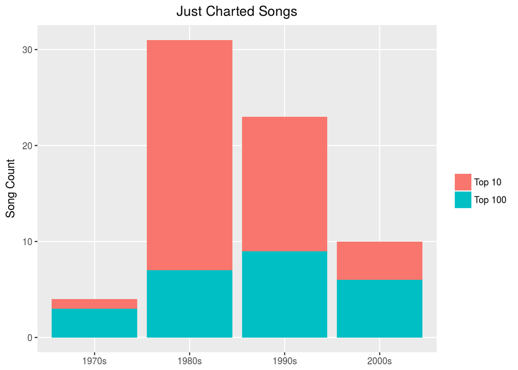

```r
prince %>%
  filter(decade != "NA", peak > 0) %>%
  group_by(decade, chart_level) %>%
  summarise(songCounts = n()) %>%
  ggplot() +
  geom_bar(aes(x = decade, y = songCounts, fill = chart_level), stat = "identity") +
  theme(plot.title = element_text(hjust = 0.5),
        legend.title = element_blank(),
        panel.grid.minor = element_blank()) +
  ggtitle("Just Charted Songs") +
  labs(x = NULL, y = "Song Count")
```

And, finally, we can look at all songs, regardless of release date or chart level:

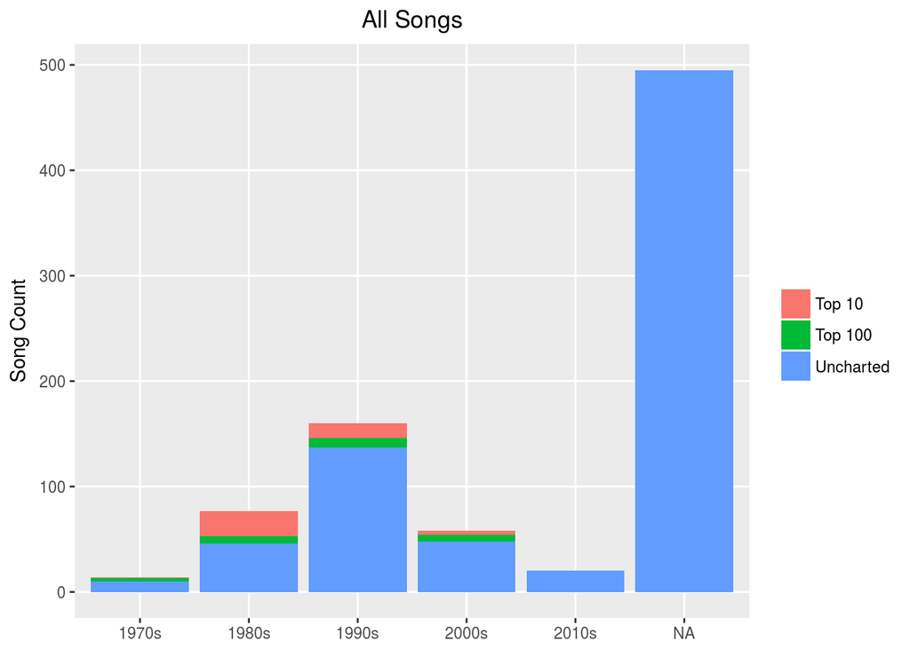

```r
prince %>%
  group_by(decade, chart_level) %>%
  summarise(songCounts = n()) %>%
  ggplot() +
  geom_bar(aes(x = decade, y = songCounts, fill = chart_level), stat = "identity") +
  theme(plot.title = element_text(hjust = 0.5),
        legend.title = element_blank(),
        panel.grid.minor = element_blank()) +
  ggtitle("All Songs") +
  labs(x = NULL, y = "Song Count")
```

[^1]: Debbie Liske, “Lyric Analysis with NLP & Machine Learning with R,” *DataCamp*, @ https://www.datacamp.com/community/tutorials/R-nlp-machine-learning